# Predicting Weight Lifting Exercise Activities

Mark Shocklee

August 22, 2015

# Summary

This project uses data from an activity tracker that collected information while the study participants performed unilateral dumbbell biceps curls both correctly and incorrectly. This project will use machine learning algorithms to train a model to correctly classify whether the exercise was done correctly or followed one of four patterns of incorrect exercise movement. The intent was to look at a variety of different machine learning algorithms. determine which one performed the best, and then use the best algorithm on a set of data where the outcome was not known. The second algorithm chosen performed so well on the training and test dataset that the decision was made to proceed onto the unknown test dataset.

This project was developed for the Practical Machine Learning class offered through Coursera by Johns Hopkins University. Obain more information on JHU offerings at: http://www.coursera.org/jhu.

# Data

This project uses data obtained from the research of: Velloso, E.; Bulling, A.; Gellersen, H.; Ugulino, W.; Fuks, H. Qualitative Activity Recognition of Weight Lifting Exercises. Proceedings of 4th International Conference in Cooperation with SIGCHI (Augmented Human ’13) . Stuttgart, Germany: ACM SIGCHI, 2013. More information available at: http://groupware.les.inf.puc-rio.br/har#ixzz3itebA4EY.

The training data for this project are available here: https://d396qusza40orc.cloudfront.net/predmachlearn/pml-training.csv.

The testing data for this project are available here: https://d396qusza40orc.cloudfront.net/predmachlearn/pml-testing.csv.

```r
# Read the files
# Note:  Based upon looking at the summary of the data and doing some checks
#        for NA and empty fields, we need to read this in a different way so
#        that the NAs, empty, and blanks will all be considered NA.
training = read.csv("./data/pml-training.csv", na.strings = c("NA", "", " "))
testing = read.csv("./data/pml-testing.csv", na.strings = c("NA", "", " "))
```

The data for this project was downloaded from the URLs on Sat Aug 15 08:57:58 2015.

The information that is being predicted is located in the classe variable. The values and descriptions of this variable are listed in the table below.

| Class | Description |
| --- | --- |
| A | Exactly according to the specification |
| B | Throwing the elbows to the front |
| C | Lifting the dumbbell only halfway |
| D | Lowering the dumbbell only halfway |
| E | Throwing the hips to the front |

# Data Cleaning

A summary was done against the training dataset (not shown to conserve space). The data files originally contained 160 variables. There were 100 fields that were removed because the data they contained was not available, was empty or was blank. The first 7 columns were also removed because they contained identifier information. This left a total of 53 variables that were used in the analysis.

# Data Analysis

The training data was further seperated into a train and test set that would be used with the machine learning algorithms. The former data frame (60%) will be used to train the machine learning algorithm, and the later (40%) will be used for cross validation. A seed was also set to support reproducability.

```r
set.seed(1024)
inTrain <- createDataPartition(y = training_cleaned$classe,
                               p = 0.6,
                               list = FALSE)
train <- training_cleaned[inTrain, ]
test <- training_cleaned[-inTrain, ]
```

At this point it would be appropriate to do some feature analysis. The first check would be to determine if there are any near zero values.

```r
nearZeroVar(train, saveMetrics = TRUE) # Looks like everything is good
```

```
##                      freqRatio percentUnique zeroVar   nzv
## roll_belt             1.173664    8.57676630   FALSE FALSE
## pitch_belt            1.056911   13.69735054   FALSE FALSE
## yaw_belt              1.006173   14.58050272   FALSE FALSE
## total_accel_belt      1.050979    0.22078804   FALSE FALSE
## gyros_belt_x          1.035253    1.05298913   FALSE FALSE
## gyros_belt_y          1.129369    0.55197011   FALSE FALSE
## gyros_belt_z          1.062911    1.35020380   FALSE FALSE
## accel_belt_x          1.004329    1.35869565   FALSE FALSE
## accel_belt_y          1.176670    1.10394022   FALSE FALSE
## accel_belt_z          1.057514    2.37771739   FALSE FALSE
## magnet_belt_x         1.059908    2.53057065   FALSE FALSE
## magnet_belt_y         1.120000    2.39470109   FALSE FALSE
## magnet_belt_z         1.014035    3.67697011   FALSE FALSE
## roll_arm             44.777778   19.57370924   FALSE FALSE
## pitch_arm            77.500000   22.53736413   FALSE FALSE
## yaw_arm              29.632353   21.45040761   FALSE FALSE
## total_accel_arm       1.008865    0.56046196   FALSE FALSE
## gyros_arm_x           1.012739    5.24796196   FALSE FALSE
## gyros_arm_y           1.336420    3.03158967   FALSE FALSE
## gyros_arm_z           1.108626    1.93614130   FALSE FALSE
## accel_arm_x           1.038835    6.40285326   FALSE FALSE
## accel_arm_y           1.158730    4.41576087   FALSE FALSE
## accel_arm_z           1.038961    6.41983696   FALSE FALSE
## magnet_arm_x          1.037736   11.09884511   FALSE FALSE
## magnet_arm_y          1.018519    7.21807065   FALSE FALSE
## magnet_arm_z          1.028571   10.57235054   FALSE FALSE
## roll_dumbbell         1.078947   87.73777174   FALSE FALSE
## pitch_dumbbell        2.390244   85.52989130   FALSE FALSE
## yaw_dumbbell          1.138889   87.33016304   FALSE FALSE
## total_accel_dumbbell  1.080049    0.34816576   FALSE FALSE
## gyros_dumbbell_x      1.005464    1.93614130   FALSE FALSE
## gyros_dumbbell_y      1.356287    2.23335598   FALSE FALSE
## gyros_dumbbell_z      1.074792    1.63043478   FALSE FALSE
## accel_dumbbell_x      1.061224    3.44769022   FALSE FALSE
## accel_dumbbell_y      1.013605    3.84680707   FALSE FALSE
## accel_dumbbell_z      1.250000    3.37126359   FALSE FALSE
## magnet_dumbbell_x     1.073394    8.90794837   FALSE FALSE
## magnet_dumbbell_y     1.297030    6.91236413   FALSE FALSE
## magnet_dumbbell_z     1.153846    5.54517663   FALSE FALSE
## roll_forearm         11.688119   14.97112772   FALSE FALSE
## pitch_forearm        56.190476   20.85597826   FALSE FALSE
## yaw_forearm          15.121795   14.09646739   FALSE FALSE
## total_accel_forearm   1.143240    0.56046196   FALSE FALSE
## gyros_forearm_x       1.022222    2.35224185   FALSE FALSE
## gyros_forearm_y       1.025532    5.99524457   FALSE FALSE
## gyros_forearm_z       1.115108    2.41168478   FALSE FALSE
## accel_forearm_x       1.265306    6.62364130   FALSE FALSE
## accel_forearm_y       1.050000    8.12669837   FALSE FALSE
## accel_forearm_z       1.040000    4.67900815   FALSE FALSE
## magnet_forearm_x      1.065217   12.09239130   FALSE FALSE
## magnet_forearm_y      1.076923   15.25135870   FALSE FALSE
## magnet_forearm_z      1.000000   13.33220109   FALSE FALSE
## classe                1.469065    0.04245924   FALSE FALSE
```

Also check for correlation between the variables to make sure there there is no overfitting.

```r
Cor <- cor(train[, names(train) != "classe"])
diag(Cor) <- 0 # Set correlation between variables and itself to zero
which(Cor > 0.8, arr.ind = TRUE) # Which variables have Correlation > 0.8
```

```
##                  row col
## yaw_belt           3   1
## total_accel_belt   4   1
## accel_belt_y       9   1
## roll_belt          1   3
## roll_belt          1   4
## accel_belt_y       9   4
## magnet_belt_x     11   8
## roll_belt          1   9
## total_accel_belt   4   9
## accel_belt_x       8  11
## magnet_arm_x      24  21
## accel_arm_x       21  24
## magnet_arm_z      26  25
## magnet_arm_y      25  26
## accel_dumbbell_x  34  28
## accel_dumbbell_z  36  29
## pitch_dumbbell    28  34
## yaw_dumbbell      29  36
```

# Machine Learning Trials

At this point I did get a bit anxious and wanted to try out some of the algorithms against the data; I haven’t yet figured out how to incorporate the information learned from the correlation check.

We are performing a classification problem, where we are trying to figure out which The type of problem is a classification Machine Learning problem because we are trying to classify the exercise that is being performed. The book “A First Course in Machine Learning” by Simon Rogers, Mark Girolami, CRC Press 2012, on page 183 suggested K-Nearest Neighbour and Support Vector Machine as good performers for classification problems, so the first algorithm that was tried was a K-Nearest Neighbours.

```r
### KNN Model 1
modelKNN <- train(classe ~ .,
                data = train, method = "knn")
predictKNN <- predict(modelKNN, train)
confusionMatrix(train$classe, predictKNN)
```

```
## Confusion Matrix and Statistics
##
##           Reference
## Prediction    A    B    C    D    E
##          A 3268   26   20   26    8
##          B   65 2103   47   39   25
##          C   13   50 1948   27   16
##          D   15   11   92 1797   15
##          E   13   51   36   39 2026
##
## Overall Statistics
##
##                Accuracy : 0.9462
##                  95% CI : (0.9419, 0.9502)
##     No Information Rate : 0.2865
##     P-Value [Acc > NIR] : < 2.2e-16
##
##                   Kappa : 0.9319
##  Mcnemar's Test P-Value : < 2.2e-16
##
## Statistics by Class:
##
##                      Class: A Class: B Class: C Class: D Class: E
## Sensitivity            0.9686   0.9384   0.9090   0.9321   0.9694
## Specificity            0.9905   0.9815   0.9890   0.9865   0.9856
## Pos Pred Value         0.9761   0.9228   0.9484   0.9311   0.9358
## Neg Pred Value         0.9874   0.9855   0.9799   0.9867   0.9933
## Prevalence             0.2865   0.1903   0.1820   0.1637   0.1775
## Detection Rate         0.2775   0.1786   0.1654   0.1526   0.1720
## Detection Prevalence   0.2843   0.1935   0.1744   0.1639   0.1838
## Balanced Accuracy      0.9795   0.9600   0.9490   0.9593   0.9775
```

The next algorithm tried was Random Forests to see if I could get a little better results, even though I realize that this will take longer to process. Based upon the favorable results, additional information was extracted about this model.

At this point I want to record a record of the mistake I made. I picked Random Forests because I had discovered a table in a reference in Google Books that suggested algorithms based upon the type of problem. My mistake is that I didn’t record the reference and after several hours of searching, I’m still unable to locate the reference.

```r
### Random Forest Model 2
modelRF <- train(classe ~ .,
                data = train, method = "rf")
predictRF <- predict(modelRF, train)
confusionMatrix(train$classe, predictRF)
```

```
## Confusion Matrix and Statistics
##
##           Reference
## Prediction    A    B    C    D    E
##          A 3348    0    0    0    0
##          B    0 2279    0    0    0
##          C    0    0 2054    0    0
##          D    0    0    0 1930    0
##          E    0    0    0    0 2165
##
## Overall Statistics
##
##                Accuracy : 1
##                  95% CI : (0.9997, 1)
##     No Information Rate : 0.2843
##     P-Value [Acc > NIR] : < 2.2e-16
##
##                   Kappa : 1
##  Mcnemar's Test P-Value : NA
##
## Statistics by Class:
##
##                      Class: A Class: B Class: C Class: D Class: E
## Sensitivity            1.0000   1.0000   1.0000   1.0000   1.0000
## Specificity            1.0000   1.0000   1.0000   1.0000   1.0000
## Pos Pred Value         1.0000   1.0000   1.0000   1.0000   1.0000
## Neg Pred Value         1.0000   1.0000   1.0000   1.0000   1.0000
## Prevalence             0.2843   0.1935   0.1744   0.1639   0.1838
## Detection Rate         0.2843   0.1935   0.1744   0.1639   0.1838
## Detection Prevalence   0.2843   0.1935   0.1744   0.1639   0.1838
## Balanced Accuracy      1.0000   1.0000   1.0000   1.0000   1.0000
```

```r
# Validate the model using the test data; looks like Random Forest is better
predictRF2 <- predict(modelRF, newdata = test)
confusionMatrix(test$classe, predictRF2)
```

```
## Confusion Matrix and Statistics
##
##           Reference
## Prediction    A    B    C    D    E
##          A 2224    7    0    0    1
##          B   16 1500    2    0    0
##          C    0   10 1349    9    0
##          D    0    0   15 1271    0
##          E    0    3    3    4 1432
##
## Overall Statistics
##
##                Accuracy : 0.9911
##                  95% CI : (0.9887, 0.993)
##     No Information Rate : 0.2855
##     P-Value [Acc > NIR] : < 2.2e-16
##
##                   Kappa : 0.9887
##  Mcnemar's Test P-Value : NA
##
## Statistics by Class:
##
##                      Class: A Class: B Class: C Class: D Class: E
## Sensitivity            0.9929   0.9868   0.9854   0.9899   0.9993
## Specificity            0.9986   0.9972   0.9971   0.9977   0.9984
## Pos Pred Value         0.9964   0.9881   0.9861   0.9883   0.9931
## Neg Pred Value         0.9971   0.9968   0.9969   0.9980   0.9998
## Prevalence             0.2855   0.1937   0.1745   0.1637   0.1826
## Detection Rate         0.2835   0.1912   0.1719   0.1620   0.1825
## Detection Prevalence   0.2845   0.1935   0.1744   0.1639   0.1838
## Balanced Accuracy      0.9957   0.9920   0.9912   0.9938   0.9989
```

```r
print(modelRF)
```

```
## Random Forest
##
## 11776 samples
##    52 predictor
##     5 classes: 'A', 'B', 'C', 'D', 'E'
##
## No pre-processing
## Resampling: Bootstrapped (25 reps)
## Summary of sample sizes: 11776, 11776, 11776, 11776, 11776, 11776, ...
## Resampling results across tuning parameters:
##
##   mtry  Accuracy   Kappa      Accuracy SD  Kappa SD
##    2    0.9863494  0.9827256  0.001496797  0.001897981
##   27    0.9868389  0.9833465  0.001862695  0.002369723
##   52    0.9799750  0.9746626  0.004771091  0.006039591
##
## Accuracy was used to select the optimal model using  the largest value.
## The final value used for the model was mtry = 27.
```

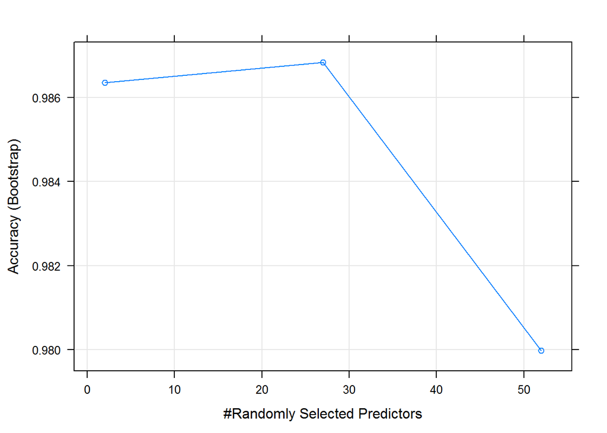

```r
plot(modelRF)
```

Due to the extremely good accuracy by the Random Forest(1) model when compared to the k-Nearest Neighbours(0.9462), I can easily conclude that the Random Forest was overfitting. Still I decided to see how the Random Forest model did against the test dataset, which yielded an accuracy of 0.9911. I decided to take a chance and run the model against the testing dataset (true unknown) and prepare it for submission. Evaluation of each of these submission files resulted in a perfect prediction. While I had planned on evaluating additional model, there didn’t seem to be any reason to.

```r
# Perform the submission
### Supplied Function
## This will write out the file to be submitted for part 2
pml_write_files = function(x){
        n = length(x)
        for(i in 1:n){
                filename = paste0("problem_id_",i,".txt")
                write.table(x[i],file=filename,quote=FALSE,row.names=FALSE,col.names=FALSE)
        }
}
predictFinal <- predict(modelRF, newdata = testing_cleaned)
pml_write_files(as.character(predictFinal))
```

When I have spare time, I would still like to evaluate additional algorithms to see how they perform, for additional practice is setting up models/using the caret package, and to actually make use of the variable correlation information.